# Neonatal Critical Care Base Dataset: Construction and Descriptive Statistics

Author

Ashley Dickson

Published

December 24, 2025

# 1 Executive Summary

This report documents the construction of the base dataset for analysing inequalities in Neonatal Critical Care (NCC) access in England. The dataset links maternity services data (MSDS) with critical care data to create a comprehensive birth-level dataset for hierarchical modelling.

**Key findings:**

- **Final dataset**: 512,032 births in financial year 2023/24
- **NCC admission rate**: 12.5% (64,109 babies)
- **Critical data quality issue identified and resolved**: MSDS tables contained 2-10x duplication due to multiple submissions
- **Data source selection**: Critical Care (CC) data preferred over MSDS for NCC admissions due to contractual reporting requirements and better data quality

## What This Means

This analysis looks at which babies receive specialist neonatal critical care in England. We found that approximately **1 in 8 babies** (12.5%) born in hospital require some form of neonatal critical care.

The data we’ve assembled will help us understand whether all babies have **equal access** to this care, regardless of their:

- Ethnic background
- Family’s socioeconomic circumstances
- Where they live in England
- Their mother’s social circumstances

Understanding these patterns is the first step toward ensuring every baby gets the care they need, when they need it.

# 2 Key Findings at a Glance

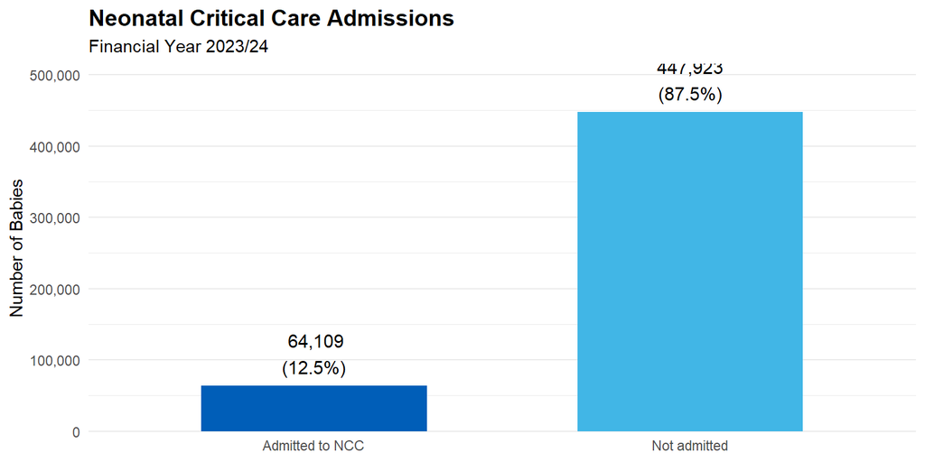

Figure 1: Overview of NCC admissions in the dataset

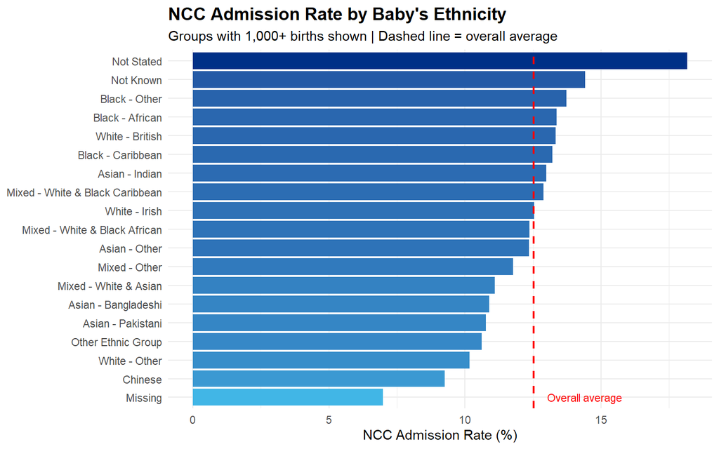

Figure 2: NCC admission rates vary by ethnic group

# 3 Dataset Construction Methodology

**NoteData Sources (click to expand)**

### 3.0.1 Primary Data Sources

1. **MSDS (Maternity Services Dataset)** - NHS Digital national maternity data:
   - `MSD401BabyDemographics_1`: Birth details and baby demographics
   - `MSD301LabourDelivery_1`: Labour and delivery information
   - `MSD101PregnancyBooking_1`: Pregnancy booking and social factors
   - `MSD001MotherDemog_1`: Mother demographics
   - `MSD402NeonatalAdmission_1`: MSDS-reported neonatal admissions
2. **Critical Care (Pbr_CC_Monthly)** - Daily-level critical care records:
   - Filtered by `CC_Type = 'NCC'` for neonatal critical care
   - Contains care levels, length of stay, and clinical details
   - Used for Payment by Results (contractual requirement)
3. **APCS (Admitted Patient Care Spells)** - `APCS_Core_Daily`:
   - Provides NHS Numbers for linkage between MSDS and CC data
   - Essential linkage table

**NoteData Linkage Strategy (click to expand)**

1. Start with MSDS births (MSD401BabyDemographics_1) as base
2. Link MSDS tables via `Labour_Delivery_ID`, `UniqPregID`, `Person_ID_Mother`
3. Link to CC data via `NHS_Number` (pseudonymised) through APCS
4. Apply 90-day date proximity filter when linking births to CC admissions
5. Compare NCC admission status from both MSDS and CC sources

**Time Period**: Financial Year 2023/24 (April 1, 2023 - March 31, 2024)

## 3.1 Data Quality: Resolving Duplication

A critical data quality issue was identified and resolved during dataset construction.

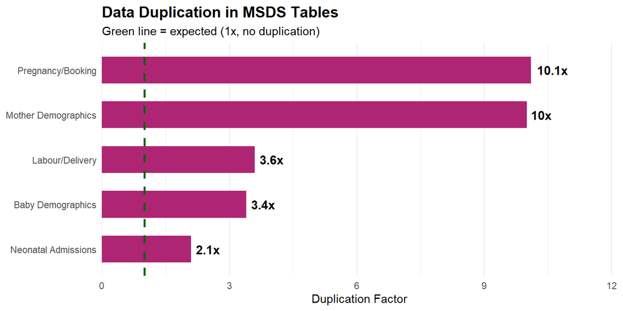

Figure 3: MSDS tables contained significant duplication that required resolution

**ImportantWhy This Matters**

**NoteTechnical Details: Deduplication Strategy (click to expand)**

Investigation revealed that **91.6% of babies** had duplicate records, with some having up to 32 duplicates. However, **45 out of 50 fields were identical** across duplicates - only submission metadata differed.

**Conclusion**: Duplicates represent multiple submissions of identical data, not different clinical events.

**Solution applied**:

```sql
ROW_NUMBER() OVER (
  PARTITION BY [natural_key]
  ORDER BY UniqSubmissionID DESC  -- Most recent submission
) AS rn

-- Then filter: WHERE rn = 1
```

## 3.2 NCC Data Source Comparison

We compared NCC admission data from two sources to ensure data quality:

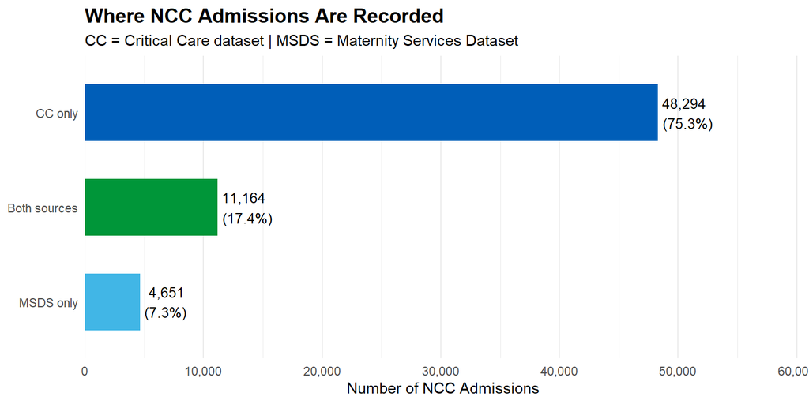

Figure 4: Critical Care data captures significantly more NCC admissions than MSDS

**TipDecision: Use Critical Care as Primary Source**

Critical Care data captures **3.76x more** NCC admissions than MSDS (due to contractual Payment by Results reporting requirements). The combined flag `NCC_Admitted = 1` if baby appears in **either** source.

# 4 Descriptive Statistics

## 4.1 Overall Dataset Summary

| Metric | Value |
| --- | --- |
| Total births in 2023/24 | 512,032 |
| NCC admissions (any source) | 64,109 |
| NCC admission rate | 12.52% |
| Births without NCC admission | 447,923 |
| Number of variables in dataset | 60 |

## 4.2 Baby Demographics

### 4.2.1 Sex Distribution and NCC Rates

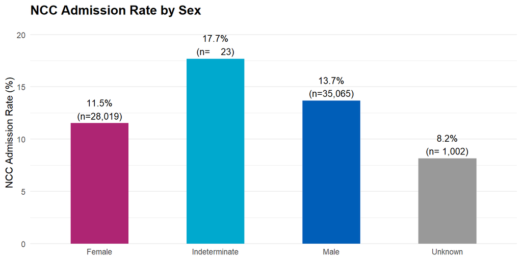

Figure 5: NCC admission rates by baby’s sex

### 4.2.2 Ethnicity Distribution

| Ethnicity | Births | NCC Admissions | NCC Rate (%) |
| --- | --- | --- | --- |
| White - British | 278,290 | 37,076 | 13.32 |
| White - Other | 52,301 | 5,318 | 10.17 |
| Asian - Pakistani | 26,160 | 2,816 | 10.76 |
| Asian - Indian | 25,287 | 3,284 | 12.99 |
| Black - African | 24,819 | 3,316 | 13.36 |
| Mixed - Other | 15,692 | 1,847 | 11.77 |
| Asian - Other | 14,851 | 1,835 | 12.36 |
| Other Ethnic Group | 12,699 | 1,347 | 10.61 |
| Missing | 12,430 | 868 | 6.98 |
| Asian - Bangladeshi | 8,796 | 958 | 10.89 |
| Mixed - White & Asian | 8,009 | 889 | 11.10 |
| Mixed - White & Black Caribbean | 6,667 | 859 | 12.88 |

## 4.3 Clinical Characteristics

### 4.3.1 Gestation Length

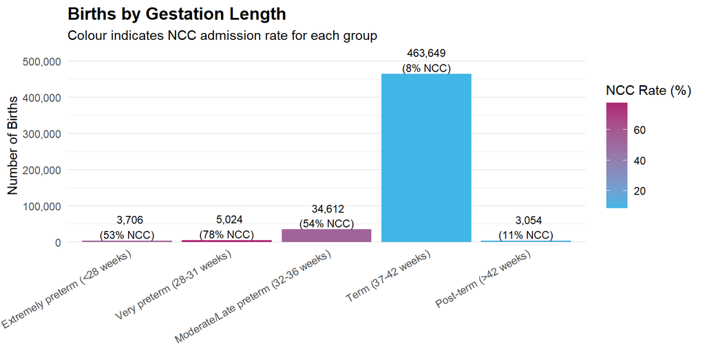

Figure 6: Distribution of gestation length at birth

### 4.3.2 Delivery Method

| Delivery Method | Births | % of Total | NCC Admissions | NCC Rate (%) |
| --- | --- | --- | --- | --- |
| Spontaneous Vertex | 233,029 | 45.5 | 18,965 | 8.14 |
| Emergency Caesarean | 120,835 | 23.6 | 26,660 | 22.06 |
| Elective Caesarean | 89,585 | 17.5 | 9,560 | 10.67 |
| Ventouse/Vacuum | 21,372 | 4.2 | 2,378 | 11.13 |
| Low Forceps | 19,607 | 3.8 | 2,462 | 12.56 |
| Other Forceps | 11,013 | 2.2 | 1,540 | 13.98 |
| Spontaneous Other Cephalic | 7,164 | 1.4 | 684 | 9.55 |
| Missing | 3,809 | 0.7 | 776 | 20.37 |
| Other | 3,615 | 0.7 | 465 | 12.86 |
| Breech | 1,675 | 0.3 | 516 | 30.81 |
| Breech Extraction | 326 | 0.1 | 102 | 31.29 |
| Other (N) | 2 | 0.0 | 1 | 50.00 |

## 4.4 NCC Admission Characteristics

### 4.4.1 Time to NCC Admission

[figure not shown]

### 4.4.2 NCC Length of Stay

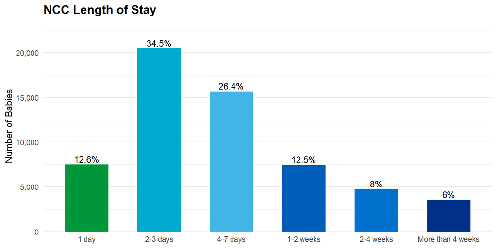

Figure 8: Distribution of NCC length of stay

## 4.5 Maternal Demographics

### 4.5.1 Mother’s Ethnicity and NCC Rates

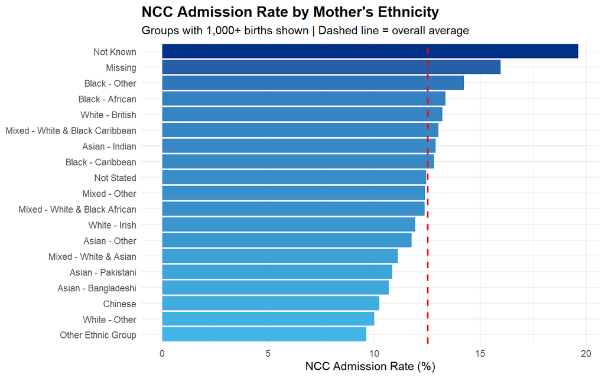

Figure 9: NCC admission rates by mother’s ethnicity

## 4.6 Social Factors (Inequality Measures)

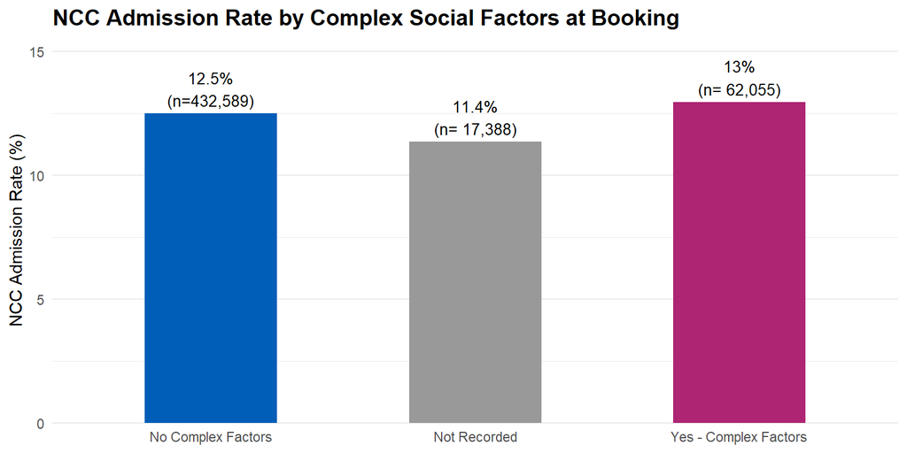

Figure 10: NCC rates are higher for mothers with complex social factors

# 5 Data Quality Assessment

## 5.1 Completeness by Key Variable

| Variable | Complete Records | Missing Records | % Complete |
| --- | --- | --- | --- |
| NHS_Number_Baby | 507,572 | 4,460 | 99.13 |
| Baby_Birth_Date | 512,032 | 0 | 100.00 |
| Baby_Sex | 512,032 | 0 | 100.00 |
| Ethnic_Category_Baby | 499,602 | 12,430 | 97.57 |
| Gestation_Length_At_Birth | 510,045 | 1,987 | 99.61 |
| Delivery_Method_Code | 508,223 | 3,809 | 99.26 |
| Ethnic_Category_Mother | 510,548 | 1,484 | 99.71 |
| NCC_Admitted | 512,032 | 0 | 100.00 |
| NCC_Hospital_Provider_Code | 59,458 | 452,574 | 11.61 |
| Mother_CCG_Residence | 240,014 | 272,018 | 46.87 |

## 5.2 Known Data Limitations

**WarningData Gaps to Address**

1. **Birth weight and Apgar scores**: Not available in main table; requires additional linkage
2. **Mother’s age**: Date of birth not available; cannot calculate maternal age
3. **Deprivation (IMD)**: Requires LSOA-to-IMD linkage
4. **NCC source discrepancies**: Only 17.4% overlap between data sources

# 6 Technical Specifications

**NoteDatabase Connection Details (click to expand)**

- **Platform**: NHS UDAL (Unified Data Access Layer) on Azure Synapse Analytics
- **Authentication**: Azure Active Directory Interactive
- **Access**: Requires UDAL data access permissions

**NoteSQL Query Structure (click to expand)**

The final query consists of several CTEs (Common Table Expressions):

1. `ncc_from_cc`: Aggregates daily CC records to baby-level
2. `apcs_link`: Provides NHS numbers for linkage
3. `ncc_cc_with_nhs`: Links CC data to NHS numbers
4. `msds_babies_raw` + `msds_babies`: Deduplicates baby demographics
5. `msds_labour_raw` + `msds_labour`: Deduplicates labour/delivery records
6. `msds_mothers_raw` + `msds_mothers`: Deduplicates mother demographics
7. `msds_pregnancy_raw` + `msds_pregnancy`: Deduplicates pregnancy/booking records
8. `msds_neonatal_adm_raw` + `msds_neonatal_adm`: Deduplicates neonatal admissions
9. `base_dataset`: Joins all deduplicated tables together

**NoteOutput Specification (click to expand)**

- **Format**: RDS (R Data Serialization)
- **Filename**: `data/ncc_base_dataset.rds`
- **Records**: 512,032
- **Fields**: 60
- **Granularity**: One record per baby born in hospital in 2023/24

# 7 Next Steps

## 7.1 For Hierarchical Modelling

The dataset is now ready for hierarchical (mixed-effects) modelling to examine:

# 8 Conclusions

1. **Successful dataset construction**: Created a clean, deduplicated birth-level dataset with 512,032 records for FY 2023/24
2. **Critical deduplication**: Identified and resolved 2-10x duplication in MSDS tables
3. **Data source selection**: Critical Care data provides more comprehensive NCC admission capture (11.6% vs 3.1%)
4. **Ready for analysis**: Dataset has appropriate granularity and key variables for inequality analysis
5. **Known limitations**: Some clinical variables (birth weight, Apgar, IMD) require additional linkage

# 9 Appendix: Variable List

**NoteComplete Variable List (click to expand)**

| Variable | Type | Non-Missing | % Complete |
| --- | --- | --- | --- |
| Person_ID_Baby | character | 512,032 | 100.0 |
| NHS_Number_Baby | integer64 | 507,572 | 99.1 |
| Baby_Birth_Date | Date | 512,032 | 100.0 |
| Baby_Birth_Time | character | 512,032 | 100.0 |
| Birth_Order | character | 492,057 | 96.1 |
| Gestation_Length_At_Birth | integer64 | 510,045 | 99.6 |
| Baby_Sex | character | 512,032 | 100.0 |
| Ethnic_Category_Baby | character | 499,602 | 97.6 |
| Pregnancy_Outcome | character | 512,032 | 100.0 |
| Baby_Birth_Financial_Year | character | 512,032 | 100.0 |
| Delivery_Method_Code | character | 508,223 | 99.3 |
| Delivered_in_Water_Indicator | character | 417,721 | 81.6 |
| Presentation_of_Fetus | character | 501,454 | 97.9 |
| Delivery_Site_Code | character | 424,503 | 82.9 |
| Baby_First_Feed_Date | Date | 380,286 | 74.3 |
| Baby_First_Feed_Breast_Milk_Indication_Code | character | 466,979 | 91.2 |
| Skin_to_Skin_Contact_Within_1_Hour_Indicator | character | 461,357 | 90.1 |
| Baby_Discharge_Date | Date | 252,585 | 49.3 |
| Baby_Death_Date | Date | 2,796 | 0.5 |
| Labour_Delivery_Onset_Method_Code | character | 503,744 | 98.4 |
| Onset_Established_Labour_Date | Date | 381,551 | 74.5 |
| Maternity_Care_Setting_Start_Intrapartum_Care | character | 308,046 | 60.2 |
| Procedure_Date_Caesarean_Section | Date | 203,512 | 39.7 |
| Mother_Admission_Date | Date | 512,032 | 100.0 |
| Mother_Discharge_Date | Date | 484,533 | 94.6 |
| Ethnic_Category_Mother | character | 510,548 | 99.7 |
| Mother_CCG_Residence | character | 240,014 | 46.9 |
| Antenatal_Booking_Date | Date | 512,032 | 100.0 |
| Pregnancy_First_Contact_Date | Date | 360,141 | 70.3 |
| Previous_Caesareans | integer | 478,043 | 93.4 |
| Previous_Live_Births | integer | 505,064 | 98.6 |
| Previous_Stillbirths | integer | 506,551 | 98.9 |
| Disability_Indicator_At_Antenatal_Booking | character | 406,799 | 79.4 |
| Mental_Health_Prediction_Detection_Indicator_At_Antenatal_Booking | character | 448,707 | 87.6 |
| Complex_Social_Factors_Indicator_At_Antenatal_Booking | character | 494,644 | 96.6 |
| Employment_Status_Mother_At_Antenatal_Booking | character | 404,717 | 79.0 |
| Org_ID_Commissioner | character | 512,032 | 100.0 |
| NCC_MSDS_Admitted | integer | 512,032 | 100.0 |
| NCC_CC_Admitted | integer | 512,032 | 100.0 |
| NCC_Admitted | integer | 512,032 | 100.0 |
| NCC_In_Both_Sources | integer | 64,109 | 12.5 |
| NCC_MSDS_First_Transfer_Date | Date | 51,283 | 10.0 |
| NCC_MSDS_First_Transfer_Time | character | 50,692 | 9.9 |
| Hours_Birth_To_NCC_MSDS | integer | 15,815 | 3.1 |
| NCC_CC_First_Admission_Date | Date | 0 | 0.0 |
| NCC_CC_First_Admission_Time | character | 0 | 0.0 |
| NCC_CC_Last_Discharge_Date | Date | 0 | 0.0 |
| Hours_Birth_To_NCC_CC | integer | 0 | 0.0 |
| NCC_CC_Total_Days | integer | 59,458 | 11.6 |
| NCC_CC_Number_Of_Periods | integer | 59,458 | 11.6 |
| NCC_CC_Gestation_Weeks | character | 0 | 0.0 |
| NCC_CC_Birth_Weight_Grams | numeric | 57,274 | 11.2 |
| NCC_CC_Level2_Days | integer64 | 59,458 | 11.6 |
| NCC_CC_Level3_Days | integer64 | 59,458 | 11.6 |
| NCC_CC_First_Unit_Function | character | 0 | 0.0 |
| NCC_CC_Admission_Source | character | 0 | 0.0 |
| NCC_CC_Final_Discharge_Status | character | 0 | 0.0 |
| NCC_CC_Final_Discharge_Destination | character | 0 | 0.0 |
| NCC_Hospital_Provider_Code | character | 59,458 | 11.6 |
| Gestation_Weeks | numeric | 510,045 | 99.6 |

**Report generated**: 2025-12-24 12:56:54.518253

**R version**: R version 4.5.2 (2025-10-31 ucrt)

**Dataset file**: `data/ncc_base_dataset.rds`